# ASX - Machine Learning

Ben Cole - s3412349

Print Date: 22/04/2019

# **Phase 1 - Introduction and Cleaning**

## Outline

The aim of this supervised machine learning project is to predict the prices of 50 different Australian Stock Exchange (ASX) shares in the year 2019. Data beginning at the 2019 calendar year through to April 2019 was used in the training and testing data sets.

### Nature of the Data

The data used was historical summary data of all shares available with a trading history in the ASX between 02/01/2019 through to business week (Mon - Fri) ending 12/04/2019. The data was provided by the website ASX Historical Data. The data was compressed into .zip files separated by calendar month between 02/01/2019 - 31/01/2019 and then by business week from 01/02/2019 - 12/04/2019. The raw data followed the same structure throughout all text files, and was not provided with headers. Each comma separated value followed the following headers:

- Ticker - the three-digit unique identifier ASX ticker code (renamed to `ASX_Ticker`)
- Date - date of trade information
- Open - price per individual share at the beginning of the day’s trade
- High - highest price recorded per individual share during the day’s trade
- Low - lowest price recorded per individual share during the day’s trade
- Close - price per individual share at the end of the day’s trade
- Volume - number of shares traded during the day

## Data Processing

### Packages

The following packages were used, with brief descriptions of their uses as comments.

```r
library(pacman)                         ## for loading multiple packages

suppressMessages(p_load(character.only = T,
                        install = F,
                        c("tidyverse",  ## thanks Hadley
                          "lubridate",  ## for handling dates
                          "forcats",    ## for categorial variables, not for felines
                          "zoo",        ## some data cleaning capabilities
                          "lemon",      ## add ons for ggplot
                          "rvest",      ## scraping web pages
                          "knitr",      ## knitting to RMarkdown
                          "kableExtra", ## add ons for knitr tables
                          "scales",     ## quick and easy formatting prettynums
                          "e1071",      ## for skew and kurtosis
                          "janitor")))  ## cleaning colnames
```

### Data - Price History

The data was read making use of a nested for loop for the files that were separated by week. Just a single for loop was required for the data that was collated into January 2019.

```r
##TODO: figure out why this is returning multiple observations for the same ASX_Ticker on the same day

Jan_file <- list.files(pattern = "jan")

unzip(Jan_file)

Jan_File_no_zip <- list.files(pattern = "jan")[!str_detect(list.files(pattern = "jan"), ".zip")]

ASX_Data_Week_Jan <- list()

ASX_Data_Month_Jan <- list()

for (k in 1:length(list.files(Jan_File_no_zip))) {

  ASX_Data_Week_Jan[[k]] <- read_csv( file.path(Jan_File_no_zip,
                                                   list.files(Jan_File_no_zip)[k]),
                                           col_names = c("ASX_Ticker",
                                                         "Date",
                                                         "Open",
                                                         "High",
                                                         "Low",
                                                         "Close",
                                                         "Volume") )

  ASX_Data_Month_Jan[[k]] <- do.call(rbind, ASX_Data_Week_Jan)

}


h <- 1

repeat {

  unzip(list.files(pattern = "week")[h])

  h <- h+1

  if (h > length(list.files(pattern = "week"))) {
    break
  }

}

Week_files <- list.files(pattern = "week")
Zip_files <- list.files(pattern = ".zip")

Week_files_no_zip <- Week_files[!Week_files %in% Zip_files]

ASX_Data_List <- list()

ASX_Data_List_Week <- list()

for (i in 1:length(Week_files_no_zip)){

  for (j in 1:length(list.files(path=Week_files_no_zip[i]))){

    ASX_Data_List_Week[[j]] <- read_csv(file.path(Week_files_no_zip[i],
                                               list.files(Week_files_no_zip[i])[j]),
                                        col_names=c("ASX_Ticker",
                                                    "Date",
                                                    "Open",
                                                    "High",
                                                    "Low",
                                                    "Close",
                                                    "Volume"))
  }

  ASX_Data_List[[i]] <- do.call(rbind, ASX_Data_List_Week)

}


ASX_Data_Frame_Jan <- do.call(rbind, ASX_Data_Month_Jan)

ASX_Data_Frame_Post_Jan <- do.call(rbind, ASX_Data_List)

ASX_Data_Frame <- rbind(ASX_Data_Frame_Jan,
                        ASX_Data_Frame_Post_Jan)

kable_styling(kable(head(ASX_Data_Frame, 20)),
              bootstrap_options = "striped", full_width = F)
```

| ASX_Ticker | Date | Open | High | Low | Close | Volume |
| --- | --- | --- | --- | --- | --- | --- |
| 14D | 20190102 | 0.310 | 0.310 | 0.300 | 0.300 | 26036 |
| 3DP | 20190102 | 0.044 | 0.045 | 0.043 | 0.043 | 854110 |
| 3PL | 20190102 | 1.200 | 1.210 | 1.195 | 1.195 | 101947 |
| 4CE | 20190102 | 0.015 | 0.015 | 0.014 | 0.014 | 483448 |
| 4DS | 20190102 | 0.056 | 0.059 | 0.054 | 0.057 | 9090917 |
| 5GN | 20190102 | 0.420 | 0.420 | 0.420 | 0.420 | 3580 |
| 88E | 20190102 | 0.018 | 0.018 | 0.017 | 0.018 | 3749963 |
| 8EC | 20190102 | 0.750 | 0.750 | 0.750 | 0.750 | 2000 |
| A2B | 20190102 | 2.220 | 2.220 | 2.100 | 2.100 | 23364 |
| A2M | 20190102 | 10.330 | 10.620 | 10.330 | 10.400 | 1678613 |
| A3D | 20190102 | 0.490 | 0.490 | 0.480 | 0.480 | 55878 |
| A4N | 20190102 | 0.096 | 0.096 | 0.095 | 0.095 | 64370 |
| AAA | 20190102 | 50.070 | 50.080 | 50.070 | 50.080 | 123005 |
| AAC | 20190102 | 1.105 | 1.120 | 1.090 | 1.100 | 309374 |
| AAJ | 20190102 | 0.005 | 0.005 | 0.005 | 0.005 | 485000 |
| AAR | 20190102 | 0.087 | 0.088 | 0.087 | 0.088 | 108115 |
| AB1 | 20190102 | 0.105 | 0.105 | 0.100 | 0.100 | 41342 |
| ABA | 20190102 | 5.230 | 5.300 | 5.230 | 5.300 | 4653 |
| ABC | 20190102 | 4.240 | 4.345 | 4.240 | 4.240 | 2025847 |
| ABL | 20190102 | 0.004 | 0.004 | 0.004 | 0.004 | 5000 |

```r
kable_styling(kable(sample_n(ASX_Data_Frame, size=20)),
              bootstrap_options = "striped", full_width = F)
```

| ASX_Ticker | Date | Open | High | Low | Close | Volume |
| --- | --- | --- | --- | --- | --- | --- |
| SRV | 20190131 | 2.860 | 2.940 | 2.860 | 2.940 | 51843 |
| KNL | 20190102 | 0.135 | 0.135 | 0.135 | 0.135 | 3703 |
| LPE | 20190116 | 0.780 | 0.810 | 0.780 | 0.810 | 12581 |
| KME | 20190102 | 0.740 | 0.740 | 0.740 | 0.740 | 10000 |
| HRR | 20190104 | 0.585 | 0.600 | 0.580 | 0.600 | 34702 |
| PNC | 20190321 | 2.510 | 2.550 | 2.470 | 2.520 | 241487 |
| HCH | 20190220 | 0.020 | 0.023 | 0.020 | 0.023 | 5597533 |
| JXT | 20190228 | 0.140 | 0.140 | 0.140 | 0.140 | 2700 |
| ARD | 20190318 | 0.014 | 0.014 | 0.014 | 0.014 | 200000 |
| MEZ | 20190107 | 3.290 | 3.290 | 3.250 | 3.250 | 6021 |
| CAJ | 20190114 | 0.260 | 0.265 | 0.255 | 0.265 | 416786 |
| SLX | 20190103 | 0.190 | 0.200 | 0.190 | 0.200 | 40939 |
| BEN | 20190409 | 9.900 | 9.910 | 9.780 | 9.830 | 1336568 |
| MX1 | 20190104 | 0.290 | 0.290 | 0.290 | 0.290 | 58628 |
| QRE | 20190124 | 5.660 | 5.690 | 5.660 | 5.690 | 5183 |
| WND | 20190103 | 1.000 | 1.000 | 1.000 | 1.000 | 137 |
| MRG | 20190412 | 0.090 | 0.090 | 0.089 | 0.089 | 148374 |
| RWC | 20190409 | 4.530 | 4.540 | 4.470 | 4.480 | 3015742 |
| AHF | 20190122 | 0.130 | 0.135 | 0.125 | 0.130 | 611417 |
| RDC | 20190125 | 1.040 | 1.040 | 1.030 | 1.035 | 142584 |

```r
# rm(ASX_Data_List, ASX_Data_List_Temp)

ASX_Data_Frame <- distinct(ASX_Data_Frame)
```

### Data - Global Industry Classification Standard

The sales data of ASX shares were enriched by adding Global Industry Classification Standard (GICS) information as well. A new table was scraped from several webpages containing all companies listed on the ASX.

```r
ASX_Html_Pages <- list()

for (i in 1:length(letters)) {

  ASX_Html_Pages[[i]] <- paste0("https://www.asx.com.au/asx/research/listedCompanies.do?coName=",
                                toupper(letters[i]))

}

ASX_Html_Pages[length(ASX_Html_Pages)+1] <- "https://www.asx.com.au/asx/research/listedCompanies.do?coName=0-9"

ASX_Html_Read_list <- list()

for (i in 1:length(ASX_Html_Pages)) {

  ASX_Html_Read_list[i] <- html_table(
    html_nodes(
      read_html(x=ASX_Html_Pages[[i]]),
      "table"),
    fill = T)

  if (i > length(ASX_Html_Pages)) {
    break
  }

}


ASX_Industry_Table <- do.call(rbind, ASX_Html_Read_list)

ASX_Industry_Table <- clean_names(ASX_Industry_Table, "parsed")

kable_styling(kable(head(ASX_Industry_Table, 20)),
              bootstrap_options = "striped", full_width = F)
```

| Company_name | ASX_code | GICS_industry_group |
| --- | --- | --- |
| NA | NA | NA |
| A-CAP ENERGY LIMITED | ACB | Energy |
| A1 INVESTMENTS & RESOURCES LTD | AYI | Diversified Financials |
| A2B AUSTRALIA LIMITED | A2B | Commercial & Professional Services |
| ABACUS PROPERTY GROUP | ABP | Real Estate |
| ABILENE OIL AND GAS LIMITED | ABL | Energy |
| ABSOLUTE EQUITY PERFORMANCE FUND LIMITED | AEG | Not Applic |
| ABUNDANT PRODUCE LIMITED | ABT | Food, Beverage & Tobacco |
| ACACIA COAL LIMITED | AJC | Energy |
| ACADEMIES AUSTRALASIA GROUP LIMITED | AKG | Consumer Services |
| ACCELERATE RESOURCES LIMITED | AX8 | Materials |
| ACCENT GROUP LIMITED | AX1 | Retailing |
| ACCENT RESOURCES NL | ACS | Materials |
| ACORN CAPITAL INVESTMENT FUND LIMITED | ACQ | Not Applic |
| ACROW FORMWORK AND CONSTRUCTION SERVICES LIMITED | ACF | Capital Goods |
| ACRUX LIMITED | ACR | Pharmaceuticals, Biotechnology & Life Sciences |
| ACTINOGEN MEDICAL LIMITED | ACW | Pharmaceuticals, Biotechnology & Life Sciences |
| ACTIVEX LIMITED | AIV | Materials |
| ADACEL TECHNOLOGIES LIMITED | ADA | Software & Services |
| ADAIRS LIMITED | ADH | Retailing |

```r
kable_styling(kable(sample_n(ASX_Industry_Table, size = 20)),
              bootstrap_options = "striped", full_width = F)
```

| Company_name | ASX_code | GICS_industry_group |
| --- | --- | --- |
| COMPUMEDICS LIMITED | CMP | Health Care Equipment & Services |
| CHALICE GOLD MINES LIMITED | CHN | Materials |
| IMPEDIMED LIMITED | IPD | Health Care Equipment & Services |
| PWR HOLDINGS LIMITED | PWH | Automobiles & Components |
| FIELD SOLUTIONS HOLDINGS LIMITED | FSG | Communication Services |
| UCW LIMITED | UCW | Consumer Services |
| BUNJI CORPORATION LIMITED | BCL | Energy |
| VIMY RESOURCES LIMITED | VMY | Energy |
| CONSOLIDATED TIN MINES LIMITED | CSD | Materials |
| ZETA PETROLEUM PLC | ZTA | Energy |
| RESOURCE DEVELOPMENT GROUP LIMITED | RDG | Materials |
| IPH LIMITED | IPH | Commercial & Professional Services |
| FREEDOM OIL AND GAS LTD | FDM | Energy |
| INGENIA COMMUNITIES GROUP | INA | Real Estate |
| MEDIGARD LIMITED | MGZ | Health Care Equipment & Services |
| INVESTIGATOR RESOURCES LTD | IVR | Materials |
| PYROLYX AG | PLX | Materials |
| CASSIUS MINING LIMITED | CMD | Materials |
| JANISON EDUCATION GROUP LIMITED | JAN | Software & Services |
| MAGNETIC RESOURCES NL | MAU | Materials |

```r
ASX_Data_Frame <- left_join(x = ASX_Data_Frame,
                            y = ASX_Industry_Table,
                            by = c("ASX_Ticker" = "ASX_code"))
```

### Descriptive Statistics

The data set was incredibly right-skewed, as outlined by the summary table below of each variable. However, all the price variables (Close, High, Low, Open) appeared to have similar measures of skew, kurtosis, and IQR.

```r
ASX_Long <- gather(ASX_Data_Frame,
                   Open:Volume,
                   key="Variable",
                   value="Value")

ASX_Summary <- summarise(group_by(ASX_Long,
                                  Variable),
                         "n ASX_Tickers" = comma(length(unique(ASX_Ticker))),
                         "n Observations" = comma(n()),
                         "Min Date" = format(ymd(min(Date)), "%d/%m/%Y"),
                         "Max Date" = format(ymd(max(Date)), "%d/%m/%Y"),
                         "Minimum" = comma(min(Value)),
                         "Q1" = comma(quantile(Value, 0.25)),
                         "Median" = comma(quantile(Value, 0.5)),
                         "Q3" = comma(quantile(Value, 0.75)),
                         "90th Percentile" = comma(quantile(Value, 0.9)),
                         "95th Percentile" = comma(quantile(Value, 0.95)),
                         "Maximum" = comma(max(Value)),
                         "Skew" = round(skewness(Value), 3),
                         "Kurtosis" = round(kurtosis(Value), 2),
                         "NA count" = comma(sum(is.na(ASX_Data_Frame))))

kable_styling(kable(ASX_Summary),
              full_width = T,
              bootstrap_options = c("striped"),
              position = "float_left")
```

| Variable | n ASX_Tickers | n Observations | Min Date | Max Date | Minimum | Q1 | Median | Q3 | 90th Percentile | 95th Percentile | Maximum | Skew | Kurtosis | NA count |
| --- | --- | --- | --- | --- | --- | --- | --- | --- | --- | --- | --- | --- | --- | --- |
| Close | 2,048 | 109,452 | 02/01/2019 | 12/04/2019 | 0 | 0 | 0 | 2 | 13 | 39 | 31,227 | 17.065 | 392.57 | 15,322 |
| High | 2,048 | 109,452 | 02/01/2019 | 12/04/2019 | 0 | 0 | 0 | 3 | 14 | 40 | 31,377 | 17.091 | 393.71 | 15,322 |
| Low | 2,048 | 109,452 | 02/01/2019 | 12/04/2019 | 0 | 0 | 0 | 2 | 13 | 39 | 30,962 | 17.053 | 392.10 | 15,322 |
| Open | 2,048 | 109,452 | 02/01/2019 | 12/04/2019 | 0 | 0 | 0 | 2 | 13 | 39 | 31,227 | 17.075 | 393.05 | 15,322 |
| Volume | 2,048 | 109,452 | 02/01/2019 | 12/04/2019 | 0 | 32,000 | 166,381 | 770,116 | 2,621,474 | 4,897,755 | 430,924,497 | 33.523 | 2272.27 | 15,322 |

### Plots

Plotting the spread of the variables only further outlines the extremity of the skew. As such, it makes sense to trim upper extreme outliers from the data set.

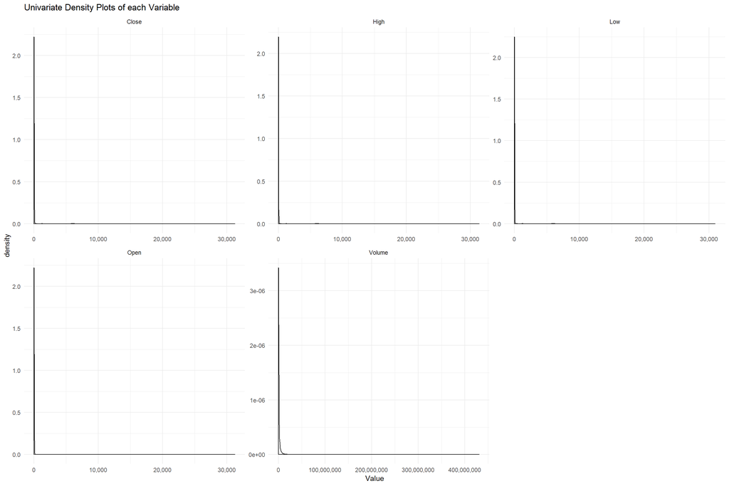

```r
ggplot(ASX_Long) +
  geom_density(aes(x=Value)) +
  scale_x_continuous(labels=comma) +
  facet_rep_wrap(~Variable, repeat.tick.labels = T,
                 scales = "free", nrow = 2) +
  ggtitle("Univariate Density Plots of each Variable") +
  theme_minimal()
```

### Filtering data

```r
ASX_Ticker_Summary <- summarise(group_by(ASX_Data_Frame, ASX_Ticker),
                                "n ASX_Tickers" = comma(length(unique(ASX_Ticker))),
                                "n Observations" = comma(n()),
                                "Min Date" = format(ymd(min(Date)), "%d/%m/%Y"),
                                "Max Date" = format(ymd(max(Date)), "%d/%m/%Y"),
                                "Minimum" = min(High),
                                "Q1" = quantile(High, 0.25),
                                "Median" = quantile(High, 0.5),
                                "Q3" = quantile(High, 0.75),
                                "90th Percentile" = quantile(High, 0.9),
                                "95th Percentile" = quantile(High, 0.95),
                                "Maximum" = max(High),
                                "Skew" = round(skewness(High), 3),
                                "Kurtosis" = round(kurtosis(High), 2),
                                "NA count" = comma(sum(is.na(ASX_Data_Frame))))


kable_styling(kable(sample_n(ASX_Ticker_Summary, 20)),
              bootstrap_options = c("striped"),
              full_width = F)
```

| ASX_Ticker | n ASX_Tickers | n Observations | Min Date | Max Date | Minimum | Q1 | Median | Q3 | 90th Percentile | 95th Percentile | Maximum | Skew | Kurtosis | NA count |
| --- | --- | --- | --- | --- | --- | --- | --- | --- | --- | --- | --- | --- | --- | --- |
| SCG | 1 | 72 | 02/01/2019 | 12/04/2019 | 3.870 | 3.9500 | 4.020 | 4.09000 | 4.1300 | 4.14450 | 4.160 | -0.043 | -1.07 | 15,322 |
| GTR | 1 | 20 | 04/01/2019 | 25/03/2019 | 0.011 | 0.0110 | 0.012 | 0.01225 | 0.0130 | 0.01300 | 0.013 | 0.074 | -1.35 | 15,322 |
| FBR | 1 | 71 | 02/01/2019 | 12/04/2019 | 0.074 | 0.0860 | 0.102 | 0.12500 | 0.1300 | 0.13600 | 0.145 | 0.146 | -1.34 | 15,322 |
| ALU | 1 | 72 | 02/01/2019 | 12/04/2019 | 21.190 | 24.9475 | 32.340 | 33.61750 | 34.2960 | 34.96800 | 35.590 | -0.330 | -1.58 | 15,322 |
| EGH | 1 | 50 | 04/01/2019 | 12/04/2019 | 0.260 | 0.2650 | 0.270 | 0.27500 | 0.2800 | 0.28550 | 0.290 | 0.823 | 0.73 | 15,322 |
| IOD | 1 | 28 | 02/01/2019 | 04/04/2019 | 0.018 | 0.0220 | 0.026 | 0.03000 | 0.0343 | 0.03500 | 0.035 | 0.274 | -1.19 | 15,322 |
| HGH | 1 | 4 | 03/01/2019 | 21/02/2019 | 1.305 | 1.3050 | 1.315 | 1.33375 | 1.3495 | 1.35475 | 1.360 | 0.493 | -1.91 | 15,322 |
| CRL | 1 | 48 | 04/01/2019 | 12/04/2019 | 0.027 | 0.0300 | 0.031 | 0.03425 | 0.0383 | 0.03965 | 0.040 | 0.847 | -0.35 | 15,322 |
| COL | 1 | 72 | 02/01/2019 | 12/04/2019 | 11.340 | 11.5925 | 11.985 | 12.38250 | 12.6945 | 12.74900 | 12.810 | 0.149 | -1.31 | 15,322 |
| KSS | 1 | 67 | 02/01/2019 | 12/04/2019 | 0.091 | 0.1000 | 0.160 | 0.22000 | 0.2700 | 0.27850 | 0.285 | 0.409 | -1.36 | 15,322 |
| CSE | 1 | 19 | 15/01/2019 | 11/04/2019 | 0.080 | 0.0995 | 0.120 | 0.13250 | 0.1550 | 0.15500 | 0.155 | 0.229 | -1.27 | 15,322 |
| SGM | 1 | 72 | 02/01/2019 | 12/04/2019 | 9.260 | 10.3775 | 10.910 | 11.39500 | 11.6890 | 11.75250 | 12.080 | -0.329 | -0.46 | 15,322 |
| GUL | 1 | 18 | 04/01/2019 | 11/04/2019 | 0.023 | 0.0270 | 0.029 | 0.02975 | 0.0300 | 0.03030 | 0.032 | -0.715 | -0.16 | 15,322 |
| EOL | 1 | 27 | 08/01/2019 | 09/04/2019 | 1.050 | 1.1050 | 1.300 | 1.52500 | 1.5700 | 1.60000 | 1.650 | 0.299 | -1.46 | 15,322 |
| GSN | 1 | 35 | 04/01/2019 | 05/04/2019 | 0.025 | 0.0300 | 0.032 | 0.03500 | 0.0366 | 0.03900 | 0.039 | 0.321 | -0.27 | 15,322 |
| WGF | 1 | 71 | 02/01/2019 | 11/04/2019 | 0.965 | 0.9750 | 0.980 | 0.98750 | 0.9920 | 0.99350 | 1.000 | 0.382 | -1.00 | 15,322 |
| BDR | 1 | 33 | 02/01/2019 | 18/02/2019 | 0.051 | 0.0540 | 0.058 | 0.06200 | 0.0640 | 0.06440 | 0.067 | 0.080 | -1.41 | 15,322 |
| MNB | 1 | 4 | 07/01/2019 | 29/01/2019 | 0.001 | 0.0010 | 0.001 | 0.00100 | 0.0010 | 0.00100 | 0.001 | NaN | NaN | 15,322 |
| XAO | 1 | 72 | 02/01/2019 | 12/04/2019 | 5694.600 | 5972.2000 | 6220.250 | 6293.20000 | 6327.0100 | 6348.71000 | 6372.600 | -0.749 | -0.79 | 15,322 |
| EUC | 1 | 71 | 02/01/2019 | 12/04/2019 | 0.020 | 0.0230 | 0.025 | 0.02700 | 0.0330 | 0.03450 | 0.039 | 1.178 | 1.11 | 15,322 |

```r
ASX_Lower <- filter(ASX_Ticker_Summary, Maximum < quantile(Maximum, 2/3))

nrow(ASX_Lower)
```

```
## [1] 1365
```

```r
ASX_Long_Lower <- filter(ASX_Long, ASX_Ticker %in% ASX_Lower$ASX_Ticker)

ASX_Data_Lower <- filter(ASX_Data_Frame, ASX_Ticker %in% ASX_Lower$ASX_Ticker)
```

#### Summary Statistics of Data After Removing Extreme ASX_Tickers

```r
ASX_Summary_Lower <- summarise(group_by(ASX_Long_Lower,
                                        Variable),
                               "n ASX_Tickers" = comma(length(unique(ASX_Ticker))),
                               "n Observations" = comma(n()),
                               "Min Date" = format(ymd(min(Date)), "%d/%m/%Y"),
                               "Max Date" = format(ymd(max(Date)), "%d/%m/%Y"),
                               "Minimum" = round(min(Value), 2),
                               "Q1" = round(quantile(Value, 0.25), 2),
                               "Median" = round(quantile(Value, 0.5), 2),
                               "Q3" = round(quantile(Value, 0.75), 2),
                               "90th Percentile" = round(quantile(Value, 0.9), 2),
                               "95th Percentile" = round(quantile(Value, 0.95), 2),
                               "Maximum" = round(max(Value), 2),
                               "Skew" = round(skewness(Value), 3),
                               "Kurtosis" = round(kurtosis(Value), 2),
                               "NA count" = comma(sum(is.na(ASX_Data_Frame))))

kable_styling(kable(ASX_Summary_Lower),
              bootstrap_options = c("striped"),
              position = "float_left",
              full_width = F)
```

| Variable | n ASX_Tickers | n Observations | Min Date | Max Date | Minimum | Q1 | Median | Q3 | 90th Percentile | 95th Percentile | Maximum | Skew | Kurtosis | NA count |
| --- | --- | --- | --- | --- | --- | --- | --- | --- | --- | --- | --- | --- | --- | --- |
| Close | 1,365 | 64,873 | 02/01/2019 | 12/04/2019 | 0 | 0.02 | 0.08 | 0.23 | 0.48 | 0.64 | 0.96 | 1.675 | 2.20 | 15,322 |
| High | 1,365 | 64,873 | 02/01/2019 | 12/04/2019 | 0 | 0.02 | 0.09 | 0.24 | 0.49 | 0.65 | 0.96 | 1.659 | 2.12 | 15,322 |
| Low | 1,365 | 64,873 | 02/01/2019 | 12/04/2019 | 0 | 0.02 | 0.08 | 0.23 | 0.48 | 0.63 | 0.96 | 1.689 | 2.27 | 15,322 |
| Open | 1,365 | 64,873 | 02/01/2019 | 12/04/2019 | 0 | 0.02 | 0.08 | 0.23 | 0.48 | 0.64 | 0.96 | 1.672 | 2.19 | 15,322 |
| Volume | 1,365 | 64,873 | 02/01/2019 | 12/04/2019 | 1 | 45873.00 | 182490.00 | 712515.00 | 2353937.80 | 4523797.80 | 430924497.00 | 33.654 | 2005.06 | 15,322 |

## Data Exploration and Visualisation

### Univariate Visualisations

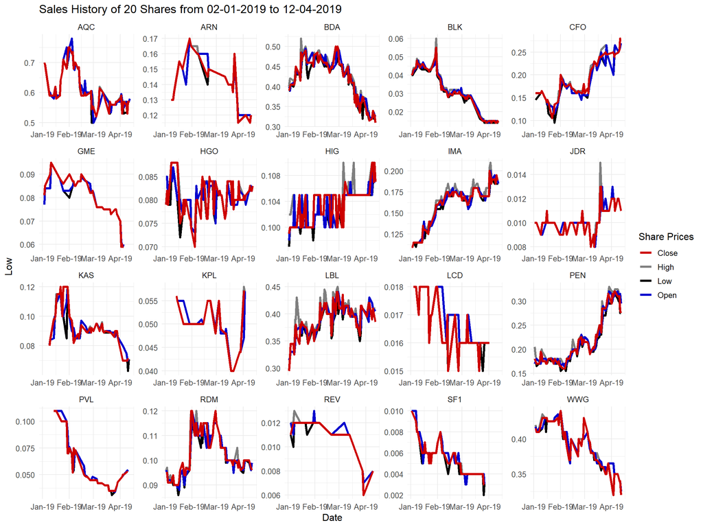

```r
ASX_Data_Lower$Date <- ymd(ASX_Data_Lower$Date)

ASX_Data_Lower <- arrange(ASX_Data_Lower, ASX_Ticker, Date)

Sample_Tickers <- sample(ASX_Data_Lower$ASX_Ticker, size = 20)

ASX_Data_Samples <- arrange(filter(ASX_Data_Lower, ASX_Ticker %in% Sample_Tickers),
                            ASX_Ticker, Date)

ggplot(ASX_Data_Samples) +
  geom_line(aes(x=Date, y=Low, col="Low"), size=1.25) +
  geom_line(aes(x=Date, y=High, col="High"), size=1.25) +
  geom_line(aes(x=Date, y=Open, col="Open"), size=1.25) +
  geom_line(aes(x=Date, y=Close, col="Close"), size=1.25) +
  scale_x_date(date_breaks = "month", date_labels = "%b-%y") +
  scale_color_manual(name = "Share Prices",
                     values = c("Open"="blue3",
                                "High"="grey50",
                                "Low"="black",
                                "Close"="red3")) +
  ggtitle("Sales History of 20 Shares from 02-01-2019 to 12-04-2019") +
  facet_rep_wrap(~ASX_Ticker, repeat.tick.labels = T,
                 scales = "free_y") +
  theme_minimal() +
  theme(text = element_text(size = 12))
```

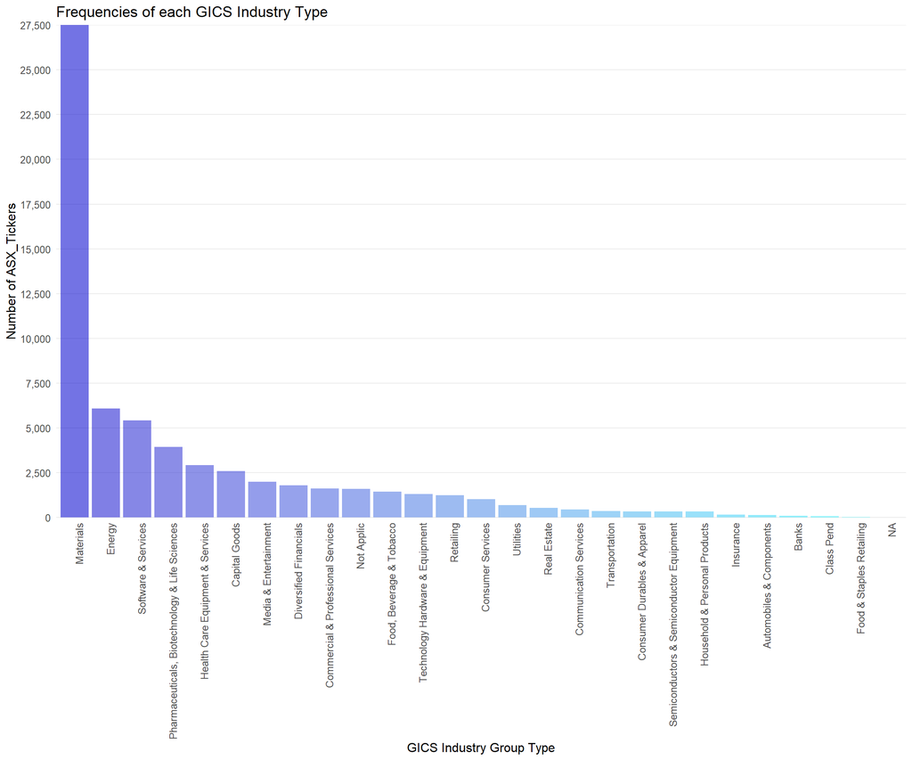

```r
fill_grad <- seq_gradient_pal("blue3",
                              "cyan")(seq(0,1,
                                                length.out = length(
                                                  unique(ASX_Data_Lower$GICS_industry_group))))

ggplot(ASX_Data_Lower, aes(x = fct_infreq(GICS_industry_group),
                           fill = fct_infreq(GICS_industry_group),
                           alpha = 0.75)) +
  geom_bar(show.legend = F) +
  ggtitle("Frequencies of each GICS Industry Type") +
  scale_y_continuous(breaks = seq(0,30000, 2500),
                     limits = c(0,NA),
                     expand = c(0,0),
                     labels = comma,
                     "Number of ASX_Tickers") +
  scale_x_discrete("GICS Industry Group Type") +
  scale_fill_manual(values = fill_grad) +
  theme_minimal() +
  theme(panel.grid.major.x = element_blank(),
        panel.grid.minor.x = element_blank(),
        panel.grid.minor.y = element_blank(),
        axis.text.x = element_text(angle = 90, hjust = 1),
        text = element_text(size = 12),
        panel.border = element_blank())
```